# CISME Data Output

File: c9 lk.dec_Dec14_1205

## Meta Data

The is the meta data extracted from your original CISME file. It will also include any updated parameters from the user.

| Object | Value |
| --- | --- |
| Filename | /msc/Data/c9 lk.dec_Dec14_1205.csv |
| pH Slope(m) | 0.05827 |
| pH Eo (b) | -0.36715 |
| cal. Buffer pH | 7.99600 |
| cal. Buffer temp | 20.53027 |
| Salinity_edit | NA |
| Salinity | 35 |
| O2 0 Phase | 60.42000 |
| O2 0 Temp | 25.00000 |
| O2 100 Phase | 28.65000 |
| O2 100 Temp | 20.43000 |
| O2 LED Current | 150.00000 |
| O2 Pressure Cal | 976.00000 |
| Total number of steps | 2 |
| Actual Run Time | 178.99998 |
| Step Number | 1 |
| Time Threshold | 180 |
| O2 Threshold | 0 |
| pH Threshold | 0.000 |
| Flow Rate | 5000.000000 |
| Actual Run Time | 238.99998 |
| Light Level | 0.000000 |
| Step Number | 2 |
| Time Threshold | 240 |
| O2 Threshold | 0 |
| pH Threshold | 0.000 |
| Flow Rate | 5000.000000 |
| Light Level | 31.000000 |
| Initial Total Alkalinity (umol/kg) | NA |
| Final Total Alkalinity (umol/kg) | NA |
| Surface Area (cm2) / Biomass (g) | 24.5 |
| Water Volume (L) | 0.088 |

## Calculated Parameters

First 5 rows of analyzed dark and light data

| Step No. | Total T(m) | Time(m) | O2 percent Sat. | O2 (umol/kg) | ISFET pH | ISFET Temp | ln (O2) | corrected O2 (uMol/kg) |
| --- | --- | --- | --- | --- | --- | --- | --- | --- |
| 1 | 0.033333 | 0.033333 | 100.23 | 203.89 | 7.965161 | 25.98713 | 5.32 | 203.90 |
| 1 | 0.050000 | 0.050000 | 100.04 | 203.51 | 7.966773 | 25.98668 | 5.32 | 203.51 |
| 1 | 0.066667 | 0.066667 | 100.23 | 203.89 | 7.966676 | 25.98596 | 5.32 | 203.90 |
| 1 | 0.083333 | 0.083333 | 100.32 | 204.09 | 7.966725 | 25.98590 | 5.32 | 204.08 |
| 1 | 0.100000 | 0.100000 | 100.23 | 203.90 | 7.966482 | 25.98542 | 5.32 | 203.90 |
| 2 | 2.983333 | 0.000000 | 101.40 | 206.37 | 7.959280 | 25.96021 | 5.32 | 206.37 |
| 2 | 3.016666 | 0.033333 | 101.50 | 206.56 | 7.957440 | 25.96050 | 5.32 | 206.57 |
| 2 | 3.033333 | 0.050000 | 101.59 | 206.76 | 7.958211 | 25.96045 | 5.32 | 206.75 |
| 2 | 3.050000 | 0.066667 | 101.59 | 206.75 | 7.958502 | 25.96103 | 5.32 | 206.75 |
| 2 | 3.066666 | 0.083333 | 101.59 | 206.75 | 7.958427 | 25.96063 | 5.32 | 206.75 |

### Total Alkalinity, TCO<sub>2</sub>, and calcification rate

**Units for the calculated parameters are as follows:**

- Total Alkalinity (uMol/Kg)
- TCO<sub>2</sub> (uMol/Kg; calculated using R package *seacarb*)
- calcification rate (nMol/cm<sup>2</sup>)

*No total alkalinity values (initial and final) were supplied so table was not constructed.*

## Run Summary Table

| Parameter | Initial Dark Value (Respiration) | Final Dark Value (Respiration) | Dark Delta (Respiration) | Initial Light Value (Photosynthesis) | Final Light Value (Photosynthesis) | Light Delta (Photosynthesis) | Overall Run Delta |
| --- | --- | --- | --- | --- | --- | --- | --- |
| Temperature | 25.990 | 25.96 | -0.030 | 25.961 | 26.033 | 0.072 | 0.043 |
| pH | 7.966 | 7.96 | -0.006 | 7.957 | 7.957 | 0.000 | -0.009 |

## Data Visualizations

### pH and % O2 saturation over time

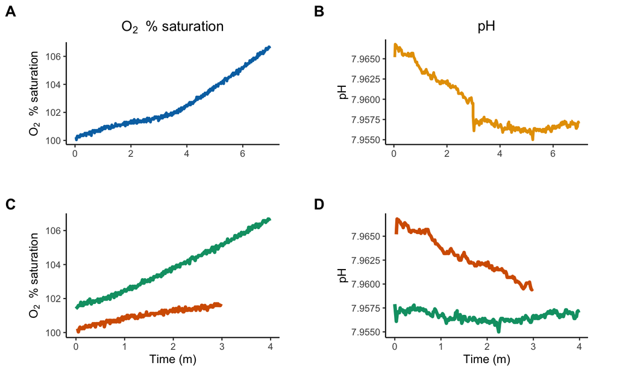

**Figure 1 |** Oxygen saturation (O<sub>2</sub> % Sat.) and pH measured in the experimental run. (**A**) The full O<sub>2</sub> % saturation (blue) and (**B**) pH (orange) throughout the duration of the experimental run. (**C**) O<sub>2</sub> and (**D**) pH are then separated out by light (green) and dark (red) components of the run (if applicable).

### Dark respiration rates

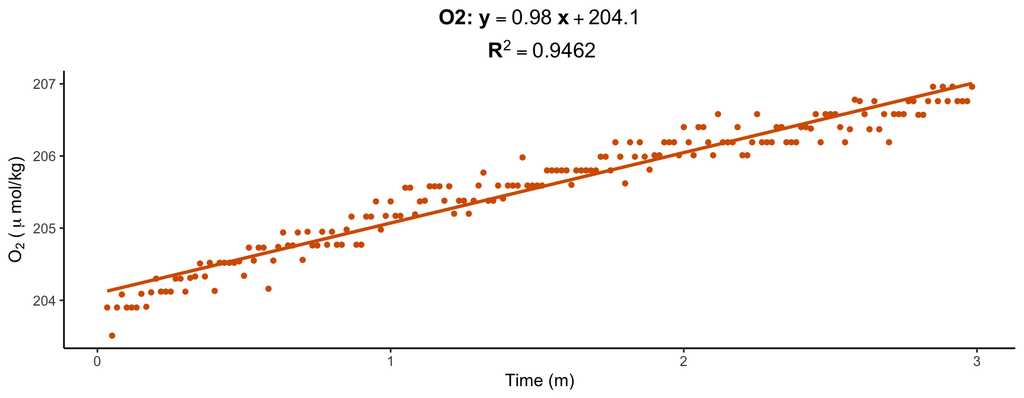

### Light photosynthesis rates

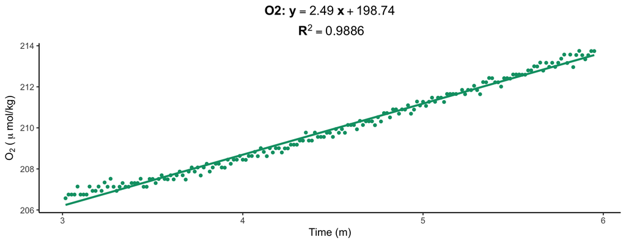

## Calculated Rates and Regression Equations

### Compiled table of O2 and TCO2 linear regression equations

| filename | parameter | light | slope | intercept | R2 | calculated rate (nMol/cm2/h) |
| --- | --- | --- | --- | --- | --- | --- |
| c9 lk.dec_Dec14_1205 | O2 | dark | 0.98 | 204.10 | 0.946 | 210.32 |
| c9 lk.dec_Dec14_1205 | O2 | light | 2.49 | 198.74 | 0.989 | 536.45 |

### Light calcification rate:

#### *No total alkalinity values (initial and final) were supplied so value was not calculated.*

## Questions?

#### If you have any questions about running this code, please contact Colleen Bove (colleenbove@gmail.com) for assistance.

This script for UNCW CISME Instruments was written by Colleen B. Bove.

### Session Information

*Script was last updated on 16 April 2022*